# 4: Clustering and classification

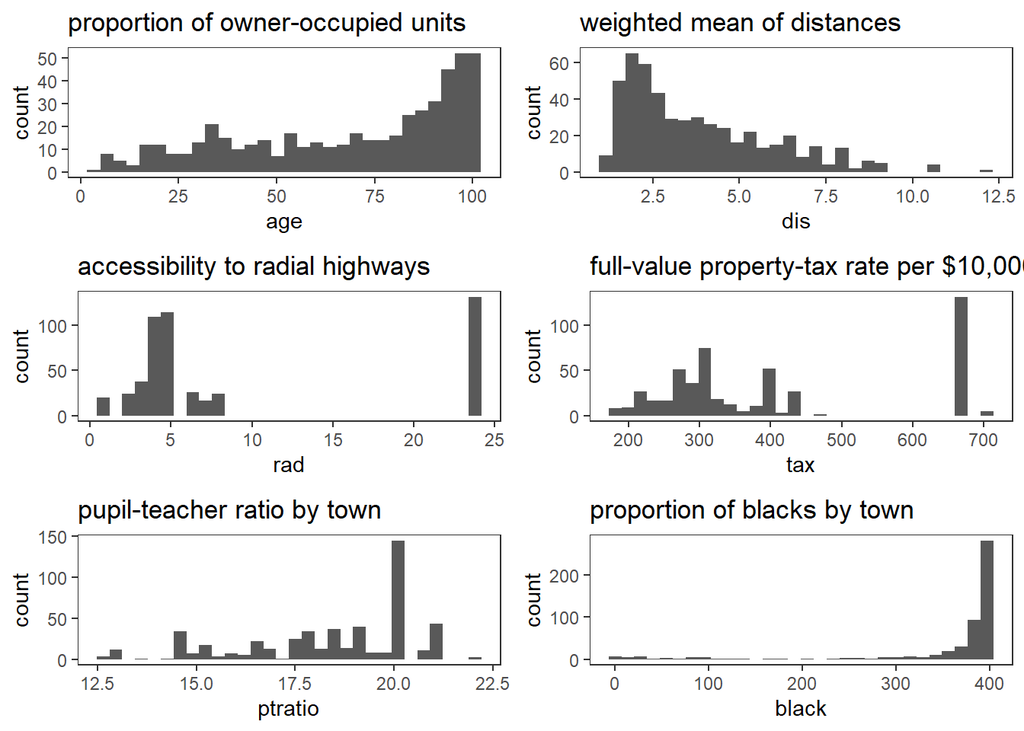

```r
grid.arrange(g,h,i,j,k,l)
```

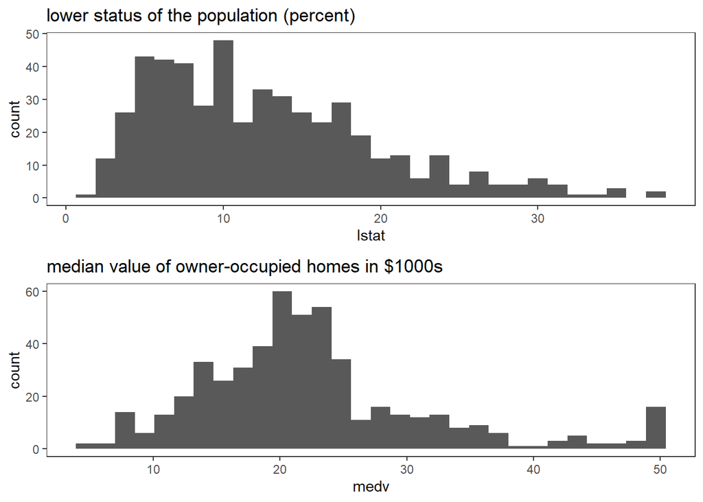

```r
grid.arrange(m,n)
```

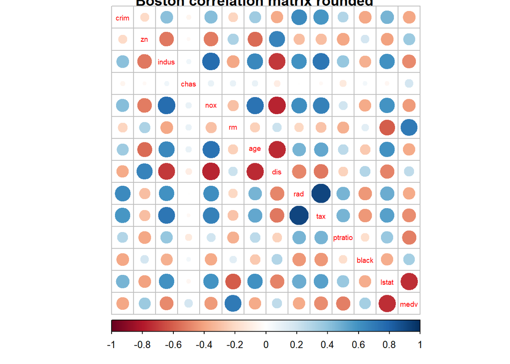

```r
# compute correlation plots with corrplot()-function
cor_matrix <- cor(Boston)
cor_matrix_r <- round(cor_matrix, digits = 2)
 # print(cor_matrix) # this does not really makes it more structured and better to get an overwiew with prettier correlation matrix
corrplot(cor_matrix_r, title = 'Boston correlation matrix rounded',
         cl.pos = "b", tl.pos = "d", tl.cex = 0.6)
```

Phuu, its a lot to describe all the relation between the variables and comment on their distribution. But lets have a try - I hope I don’t forget that much:

**The distribution of the variables:**

1. ‘crim’ - the mean of this variables is 3.6 and the value of the median in not much higher too; maximum is much higher at ~89
2. ‘zn’ - I can’t see any special distribution, but the median is 0 and the mean is around 11
3. ‘indus’ - again no special distribution, but the values range from 0 to a max of 27.74 with a very common value of ~19, the mean is 11.14
4. ‘chas’ - values either 0 or 1, but 0 is much more frequent, more than 400 times
5. ‘nox’ - I detected no special distrubution for the values between 0 and 1, the mean is 0.55
6. ‘rm’ - looks like a normal or t distribution with a mean of 6.285
7. ‘age’ - values between 0 and 100, mean is 68
8. ‘dis’ - mean of 3.7, looks a little bit like a poisson distribution with most frequent value of around 2
9. ‘rad’ - min of 1 and max of 24, I cant see any distribution pattern, the most frequent value is 24!
10. ‘tax’ - min of 187 and max of 711 with again no visible pattern in the distribution
11. ‘ptratio’ - values between 12.6 and 22, the most frequent value seems to be slightly above 20, the mean is18.46
12. ‘black’ - the distribution seems to be exponential with a max of 396
13. ‘lstat’ - looks like a poisson distribution with the most frequent value around ~8 and a mean of 12.65
14. ‘medv’ - I cant observe any pattern, the min is 5, the max is 50 and the mean 22.53 - well one could assume a normal distribution, but I not really agree to this!

**Correlation between the variables**

To shorten this a little bit I will only write about the positive or negative correlations that are visible from the correlation plot:

- strong negative correlation: dis~age; dis~nox; dis~indus; lstat~medv, lstat~rm …
- strong positive correlation: rad~tax; indus~tax, indux~nox, age~nox …

### Some preparation in the dataset (scaling, new variable etc)

The data set should be standardized and some other computation and data wrangling tasks should be done:

```r
# scale dataset and print summary statistics
boston_scaled <- Boston %>% scale()
summary(boston_scaled)
```

```
##       crim                 zn               indus              chas
##  Min.   :-0.419367   Min.   :-0.48724   Min.   :-1.5563   Min.   :-0.2723
##  1st Qu.:-0.410563   1st Qu.:-0.48724   1st Qu.:-0.8668   1st Qu.:-0.2723
##  Median :-0.390280   Median :-0.48724   Median :-0.2109   Median :-0.2723
##  Mean   : 0.000000   Mean   : 0.00000   Mean   : 0.0000   Mean   : 0.0000
##  3rd Qu.: 0.007389   3rd Qu.: 0.04872   3rd Qu.: 1.0150   3rd Qu.:-0.2723
##  Max.   : 9.924110   Max.   : 3.80047   Max.   : 2.4202   Max.   : 3.6648
##       nox                rm               age               dis
##  Min.   :-1.4644   Min.   :-3.8764   Min.   :-2.3331   Min.   :-1.2658
##  1st Qu.:-0.9121   1st Qu.:-0.5681   1st Qu.:-0.8366   1st Qu.:-0.8049
##  Median :-0.1441   Median :-0.1084   Median : 0.3171   Median :-0.2790
##  Mean   : 0.0000   Mean   : 0.0000   Mean   : 0.0000   Mean   : 0.0000
##  3rd Qu.: 0.5981   3rd Qu.: 0.4823   3rd Qu.: 0.9059   3rd Qu.: 0.6617
##  Max.   : 2.7296   Max.   : 3.5515   Max.   : 1.1164   Max.   : 3.9566
##       rad               tax             ptratio            black
##  Min.   :-0.9819   Min.   :-1.3127   Min.   :-2.7047   Min.   :-3.9033
##  1st Qu.:-0.6373   1st Qu.:-0.7668   1st Qu.:-0.4876   1st Qu.: 0.2049
##  Median :-0.5225   Median :-0.4642   Median : 0.2746   Median : 0.3808
##  Mean   : 0.0000   Mean   : 0.0000   Mean   : 0.0000   Mean   : 0.0000
##  3rd Qu.: 1.6596   3rd Qu.: 1.5294   3rd Qu.: 0.8058   3rd Qu.: 0.4332
##  Max.   : 1.6596   Max.   : 1.7964   Max.   : 1.6372   Max.   : 0.4406
##      lstat              medv
##  Min.   :-1.5296   Min.   :-1.9063
##  1st Qu.:-0.7986   1st Qu.:-0.5989
##  Median :-0.1811   Median :-0.1449
##  Mean   : 0.0000   Mean   : 0.0000
##  3rd Qu.: 0.6024   3rd Qu.: 0.2683
##  Max.   : 3.5453   Max.   : 2.9865
```

```r
# create a categorial variable
boston_scaled <- boston_scaled %>%
  as.data.frame() %>%
  mutate(crim = as.numeric(crim)) #change class to numeric
bins <- quantile(boston_scaled$crim) # get bins from quantiles of the scaled variable
crime <- cut(boston_scaled$crim, breaks = bins, include.lowest = TRUE,
             labels = c("low", "med_low", "med_high", "high")) # create categorial variable
boston_scaled <- boston_scaled %>% mutate(crim = crime) # update old crime variable in dataset

# devide dataset in train and test dataset
set.seed(2)
ind <- sample(nrow(boston_scaled),  size = nrow(boston_scaled) * 0.8) # choose randomly 80% of the rows
train <- boston_scaled[ind, ] # create train set by selecting for the randomly chosen row numbers
test <- boston_scaled[-ind,] # create test set by selecting for all other rows
correct_classes_test <- test$crim # save the correct classes from test data
test <- select(test, -crim) # remove the crime variable from test data
```

The data is scaled now - the mean is by definition 0 and sd should be 1. So the values of each variable range now around of 0 in both positive and negative direction. Additionally, extremely high or low values / outliner are now closer to the other values by scaling.

### Fit linear discriminant analysis

```r
# fit lda
lda.fit <- lda(crim ~ ., data = train) # fit lda, crime as target variable, all others as predictors
lda.fit # print output
```

```
## Call:
## lda(crim ~ ., data = train)
##
## Prior probabilities of groups:
##       low   med_low  med_high      high
## 0.2772277 0.2524752 0.2277228 0.2425743
##
## Group means:
##                   zn      indus         chas        nox         rm        age
## low       0.86204970 -0.8925108 -0.096565664 -0.8524265  0.4703454 -0.8477852
## med_low  -0.09840341 -0.3099815 -0.002135914 -0.5803953 -0.1260931 -0.3756429
## med_high -0.35488033  0.1966979  0.241205746  0.4605733  0.1072177  0.4153033
## high     -0.48724019  1.0171960 -0.111631099  1.0492138 -0.3711513  0.7890846
##                 dis        rad        tax     ptratio       black       lstat
## low       0.8033209 -0.6865511 -0.7677708 -0.45909998  0.38545221 -0.77402343
## med_low   0.3415803 -0.5652704 -0.5096445 -0.07184181  0.32347660 -0.14433573
## med_high -0.3956872 -0.3976510 -0.2976907 -0.34647468  0.08212152  0.08179606
## high     -0.8338705  1.6373367  1.5134896  0.77985517 -0.77254106  0.81544757
##                 medv
## low       0.56289622
## med_low   0.01764596
## med_high  0.16094600
## high     -0.64751418
##
## Coefficients of linear discriminants:
##                 LD1         LD2         LD3
## zn       0.07913803  0.57024603 -0.89426580
## indus    0.02196451 -0.25128076  0.26455472
## chas    -0.09221941 -0.08799328  0.11307037
## nox      0.37670131 -0.84508183 -1.31974486
## rm      -0.07008592 -0.10753540 -0.15657480
## age      0.20180001 -0.26322294 -0.10067870
## dis     -0.06859907 -0.25334328  0.07106987
## rad      3.12255116  0.99675266 -0.16321275
## tax      0.07698646 -0.05435089  0.55053140
## ptratio  0.09081238  0.02934556 -0.22234030
## black   -0.10812881 -0.01059619  0.10886239
## lstat    0.23139419 -0.27892653  0.41141914
## medv     0.19542252 -0.38411240 -0.16965709
##
## Proportion of trace:
##    LD1    LD2    LD3
## 0.9513 0.0357 0.0130
```

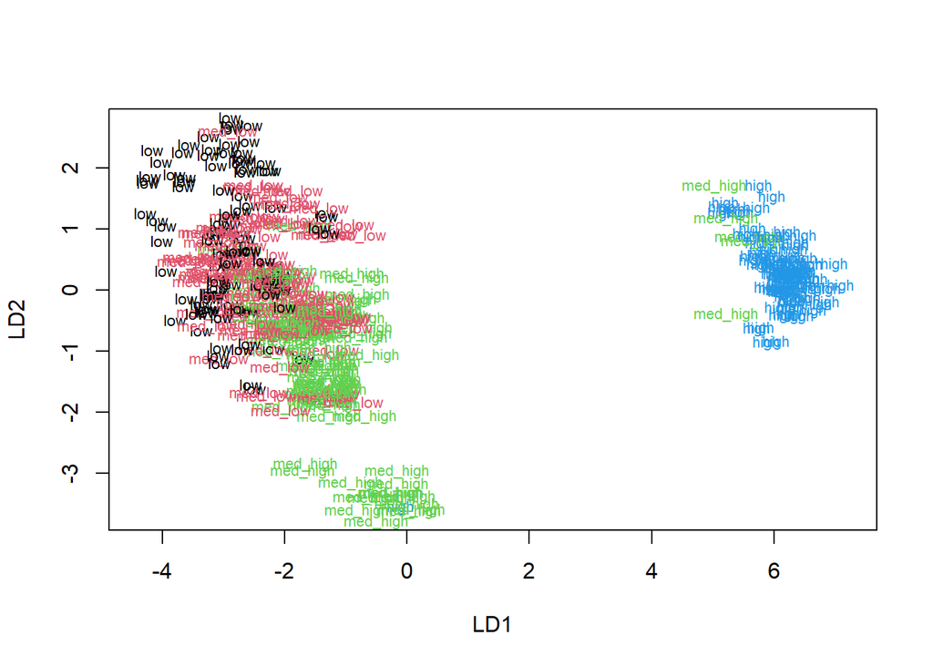

```r
# the function for lda biplot arrows - I changed nothing from the exercise
lda.arrows <- function(x, myscale = 1, arrow_heads = 0.1, color = "red", tex = 0.75, choices = c(1,2)){
  heads <- coef(x)
  graphics::arrows(x0 = 0, y0 = 0,
         x1 = myscale * heads[,choices[1]],
         y1 = myscale * heads[,choices[2]], col=color, length = arrow_heads)
  text(myscale * heads[,choices], labels = row.names(heads),
       cex = tex, col=color, pos=3)}

classes <- as.numeric(train$crim) # save crime classes as numeric, hm - something went wrong

# plot lda result together with arrows, this wont work in the knitted document!
plot(lda.fit, dimen = 2, col = classes) # dimen sets the number of discriminants
```

```r
# lda.arrows(lda.fit, myscale = 2)
```

Its not needed to comment on the output - but this looks not that trustworthy to me at all! Why do there is exactly this result und why are the classes that randomly distributed in various groups?

### predict values from LDA

Firstly, I will do some preparations to afterwards predict classes with the LDA data on the test dataset and compare the results:

```r
summary(correct_classes_test) # I saved the categories already some time earlier
```

```
##      low  med_low med_high     high
##       15       24       34       29
```

```r
names(test) # the crime variable has already been removed in a rchunk above
```

```
##  [1] "zn"      "indus"   "chas"    "nox"     "rm"      "age"     "dis"
##  [8] "rad"     "tax"     "ptratio" "black"   "lstat"   "medv"
```

```r
lda.pred <- predict(lda.fit, newdata = test) # predict with new data from the test set
table(correct = correct_classes_test, predicted = lda.pred$class) # provide cross tabulation
```

```
##           predicted
## correct    low med_low med_high high
##   low       13       2        0    0
##   med_low    5      17        2    0
##   med_high   0      16       17    1
##   high       0       0        0   29
```

### calculate distances and k-mean algorithm

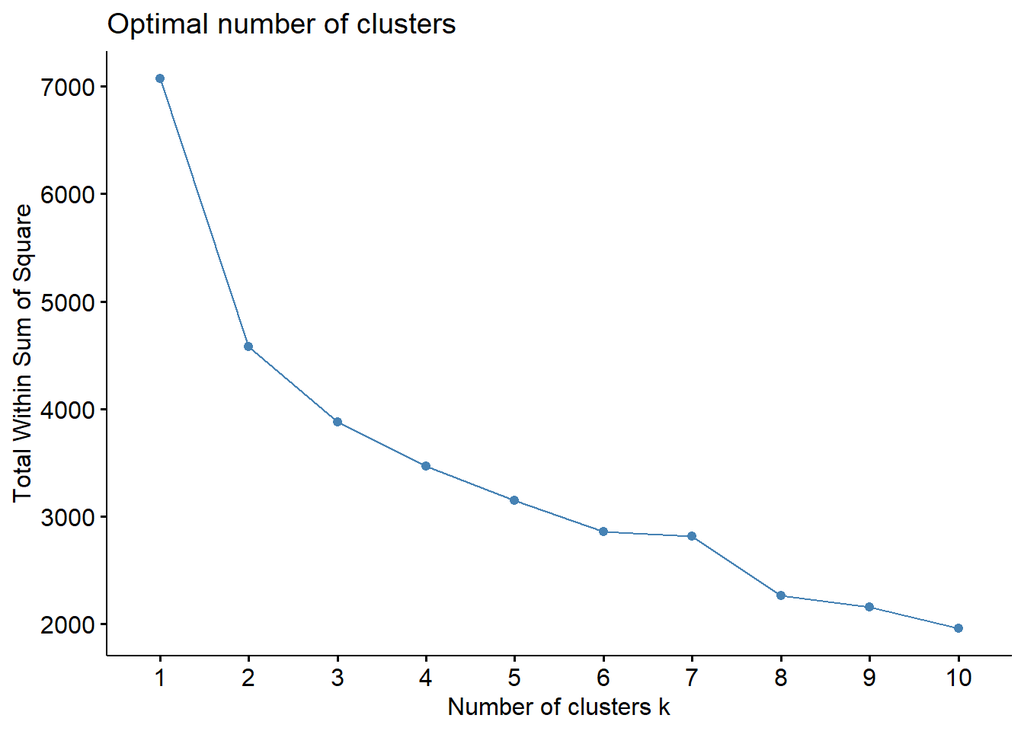

```r
# preparation
data(Boston) # load dataset
Boston <- scale(Boston) # scale dataset

# calculate distances
dist_eu <- dist(Boston, method = 'euclidean') # calculate euclidean distance
dist_man <- dist(Boston, method = 'manhattan') # calculate manhattan distance
# there are several other methods that can be used!  - ?dist

# find proper number of classes for kmeans approach
fviz_nbclust(Boston, FUNcluster = kmeans, method = "wss") # kmeans is a function:D
```

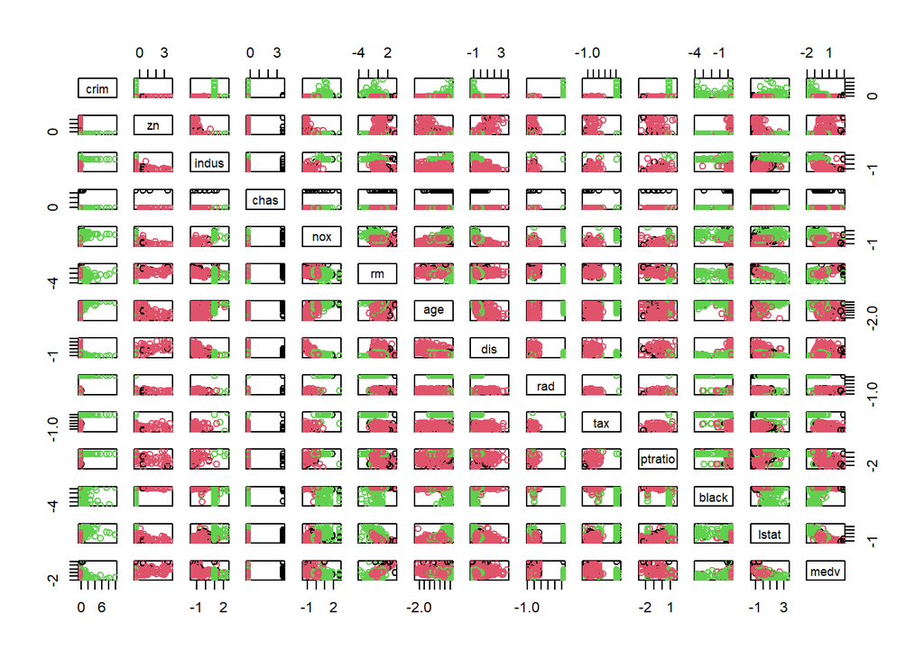

```r
# k-means algorithm
km2 <- kmeans(Boston, centers = 2) # 2 classes could be okay, they have to be set proir
km3 <- kmeans(Boston, centers = 3)
km4 <- kmeans(Boston, centers = 4)
km5 <- kmeans(Boston, centers = 5)

# plot results
pairs(Boston, col = km3$cluster) # phuuu, that looks overwhelming
```

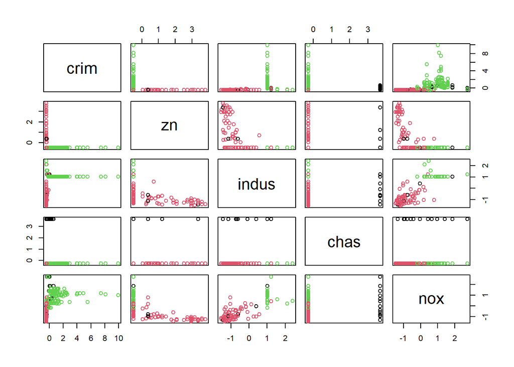

```r
# plot results more in detail
pairs(Boston[,1:5], col = km3$cluster)
```

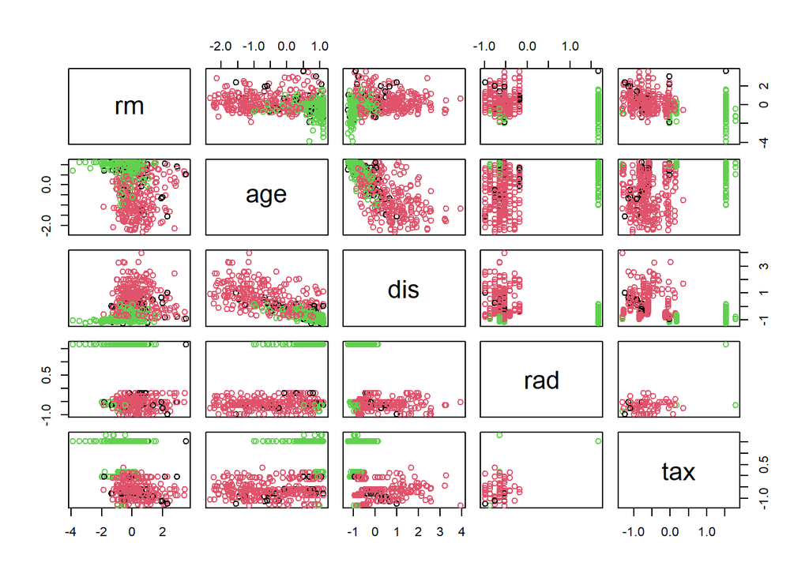

```r
pairs(Boston[,6:10], col = km3$cluster)
```

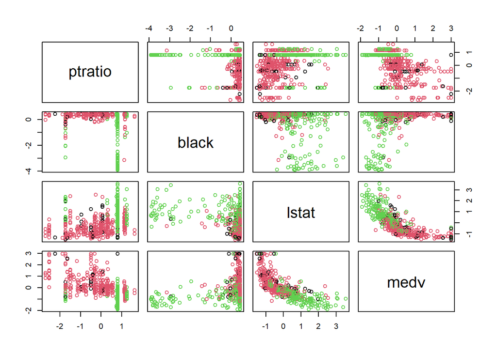

```r
pairs(Boston[,11:14], col = km3$cluster)
```

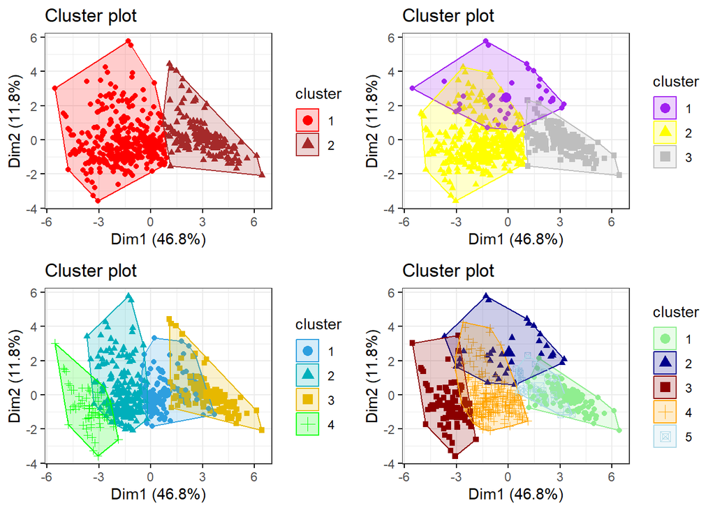

```r
# a more advanced plot
p_2 <- fviz_cluster(km2, data = Boston,
             palette = c("red", "brown"),
             geom = "point",
             ellipse.type = "convex",
             ggtheme = theme_bw())
p_3 <- fviz_cluster(km3, data = Boston,
             palette = c('purple', 'yellow', 'grey'),
             geom = "point",
             ellipse.type = "convex",
             ggtheme = theme_bw())
p_4 <- fviz_cluster(km4, data = Boston,
             palette = c("#2E9FDF", "#00AFBB", "#E7B800", 'green'),
             geom = "point",
             ellipse.type = "convex",
             ggtheme = theme_bw())
p_5 <- fviz_cluster(km5, data = Boston,
             palette = c("lightgreen", "darkblue", "darkred", 'orange', 'lightblue'),
             geom = "point",
             ellipse.type = "convex",
             ggtheme = theme_bw())
grid.arrange(grobs = list(p_2,p_3, p_4, p_5), nrow = 2)
```

With the k-means method you have to decide on the number of classes before running the algorithm. Therefor I used the elbow method - it is recommended to set the classes where the total within sum of sqaures does not decrease that much anymore. This point normally is called ‘elbow’. In this example there is not really an elbow - but maybe at 2, 3 or 4 (5) classes. Firstly, I tried 4, but after plotting 3 looked much better, so I chose this. To be sure I also plotted 2 and 5. To interpret the result: This is very hard for me, but I have a try: The output takes k-means results and the original data as arguments. It shows that somehow the 3 classes that have been build up are distinct even though there is overlap with group 1! Especially, between class 1 and 2 the boarder seems to be a bit random. The plot with 2 clusters much better - there is no overlap at all! The plots of 4 and 5 groups look a bit messy. All in all, I think it is reasonable to stay with 2 categories that have been built up with the k-means approach. NB: Somehow I had troubles with the plot of the 3 categories - the groups were built up slightly different each time I run the plot. Do you have an idea what causes this issues and how to solve this (statistically or in coding)?

### Bonus

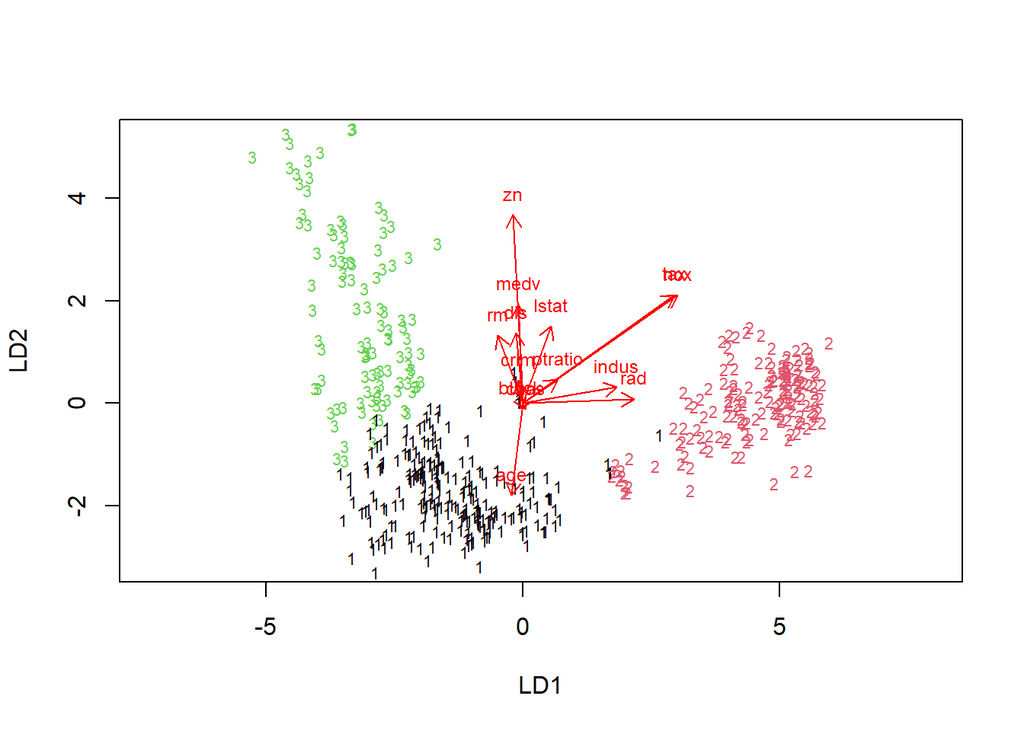

```r
set.seed(2)
data(Boston) # reload dataset
Boston <- Boston %>% scale() # standardize dataset
km3 <- kmeans(Boston, centers = 3) # calculate kmeans
lda.fit2 <- lda(x = Boston, grouping = km3$cluster) # perform discriminant analysis on scaled Boston data providing the groups
plot(lda.fit2, dimen = 2, col = km3$cluster) # plot in biplot
lda.arrows(lda.fit2, myscale = 3) # add arrows
```